# Assignment

Magdalene

2023-11-01

#This is the part about data exploration1

```r
meta <- read.csv("metaFile.csv")
library(knitr)
kable(meta)
```

| sample_id | Participant | Treatment |
| --- | --- | --- |
| sample_1 | C | 4 |
| sample_2 | B | 3 |
| sample_3 | B | 2 |
| sample_4 | C | 1 |
| sample_5 | C | 3 |
| sample_6 | A | 4 |
| sample_7 | B | 0 |
| sample_8 | A | 1 |
| sample_9 | B | 4 |
| sample_10 | C | 0 |
| sample_11 | A | 2 |
| sample_12 | A | 3 |
| sample_13 | B | 1 |
| sample_14 | C | 2 |
| sample_15 | A | 0 |
| sample_16 | C | 4 |
| sample_17 | B | 3 |
| sample_18 | B | 2 |
| sample_19 | C | 1 |
| sample_20 | C | 3 |
| sample_21 | A | 4 |
| sample_22 | B | 0 |
| sample_23 | A | 1 |
| sample_24 | B | 4 |
| sample_25 | C | 0 |
| sample_26 | A | 2 |
| sample_27 | A | 3 |
| sample_28 | B | 1 |
| sample_29 | C | 2 |
| sample_30 | A | 0 |
| sample_31 | C | 4 |
| sample_32 | B | 3 |
| sample_33 | B | 2 |
| sample_34 | C | 1 |
| sample_35 | C | 3 |
| sample_36 | A | 4 |
| sample_37 | B | 0 |
| sample_38 | A | 1 |
| sample_39 | B | 4 |
| sample_40 | C | 0 |
| sample_41 | A | 2 |
| sample_42 | A | 3 |
| sample_43 | B | 1 |
| sample_44 | C | 2 |
| sample_45 | A | 0 |
| sample_46 | C | 4 |
| sample_47 | B | 3 |
| sample_48 | B | 2 |
| sample_49 | C | 1 |
| sample_50 | C | 3 |

```r
#i
dim(meta)
```

```
## [1] 50  3
```

```r
#ii
table(meta$Treatment)
```

```
##
##  0  1  2  3  4
##  9 10 10 11 10
```

```r
#ii
table(meta$Participant)
```

```
##
##  A  B  C
## 15 17 18
```

```r
#iv
library(dplyr)
filter(meta, Treatment==0 | Treatment==2 | Treatment==4)
```

```
##    sample_id Participant Treatment
## 1   sample_1           C         4
## 2   sample_3           B         2
## 3   sample_6           A         4
## 4   sample_7           B         0
## 5   sample_9           B         4
## 6  sample_10           C         0
## 7  sample_11           A         2
## 8  sample_14           C         2
## 9  sample_15           A         0
## 10 sample_16           C         4
## 11 sample_18           B         2
## 12 sample_21           A         4
## 13 sample_22           B         0
## 14 sample_24           B         4
## 15 sample_25           C         0
## 16 sample_26           A         2
## 17 sample_29           C         2
## 18 sample_30           A         0
## 19 sample_31           C         4
## 20 sample_33           B         2
## 21 sample_36           A         4
## 22 sample_37           B         0
## 23 sample_39           B         4
## 24 sample_40           C         0
## 25 sample_41           A         2
## 26 sample_44           C         2
## 27 sample_45           A         0
## 28 sample_46           C         4
## 29 sample_48           B         2
```

```r
#v
filter(meta, Participant=="A" | Participant=="C")
```

```
##    sample_id Participant Treatment
## 1   sample_1           C         4
## 2   sample_4           C         1
## 3   sample_5           C         3
## 4   sample_6           A         4
## 5   sample_8           A         1
## 6  sample_10           C         0
## 7  sample_11           A         2
## 8  sample_12           A         3
## 9  sample_14           C         2
## 10 sample_15           A         0
## 11 sample_16           C         4
## 12 sample_19           C         1
## 13 sample_20           C         3
## 14 sample_21           A         4
```

[output cut: 19 more lines]

```r
#vi
table(meta$Treatment, meta$Participant)
```

```
##
##     A B C
##   0 3 3 3
##   1 3 3 4
##   2 3 4 3
##   3 3 4 4
##   4 3 3 4
```

#This is the part for data exploration2

```r
#i
assignment <- read.csv("AssignmentFile.csv")
head(assignment)
```

```
##    samples     Conc1    Conc2    Conc3
## 1 sample_1 5.9380487 2.287777 3.248762
## 2 sample_2 3.3984629 4.050884 3.235988
## 3 sample_3 1.9464752 1.291823 1.259798
## 4 sample_4 1.7504377 4.508815 2.615356
## 5 sample_5 2.9031939 2.600606 1.666213
## 6 sample_6 0.7466299 3.521295 1.336153
```

```r
dim(assignment)
```

```
## [1] 50  4
```

```r
#ii
concs <- assignment[, c("Conc1", "Conc2", "Conc3")]
head(concs)
```

```
##       Conc1    Conc2    Conc3
## 1 5.9380487 2.287777 3.248762
## 2 3.3984629 4.050884 3.235988
## 3 1.9464752 1.291823 1.259798
## 4 1.7504377 4.508815 2.615356
## 5 2.9031939 2.600606 1.666213
## 6 0.7466299 3.521295 1.336153
```

```r
apply(concs, 2, mean)
```

```
##    Conc1    Conc2    Conc3
## 2.235910 2.631801 2.579690
```

```r
#iii
Concmean = rowMeans(assignment[2:4])
Concmean
```

```
##  [1] 3.824863 3.561779 1.499365 2.958203 2.390004 1.868026 2.409794 1.419867
##  [9] 3.306693 2.288922 2.056538 1.599757 2.451226 2.901506 3.258827 1.753767
## [17] 2.443834 2.657674 1.782624 2.034364 1.998999 2.163061 2.544692 2.452164
## [25] 2.092057 3.003388 3.313401 1.765348 1.624170 3.037058 2.448267 2.038269
## [33] 2.833067 1.957261 1.668823 2.192923 2.616311 3.646680 2.841996 2.949213
## [41] 3.229693 2.329251 3.211285 2.842079 2.998275 2.744949 1.683616 2.672564
## [49] 2.434259 2.322598
```

```r
#iv
assignment <- mutate(assignment, Concmean=rowMeans(assignment[2:4]))

#v
sapply(assignment[,2:5], min)
```

```
##       Conc1       Conc2       Conc3    Concmean
##  0.07948294  0.68558588 -0.27549366  1.41986718
```

```r
sapply(assignment[,2:5], max)
```

```
##    Conc1    Conc2    Conc3 Concmean
## 5.938049 4.770579 5.432420 3.824863
```

```r
sapply(assignment[,2:5], median)
```

```
##    Conc1    Conc2    Conc3 Concmean
## 2.222266 2.596348 2.642415 2.446051
```

```r
sapply(assignment[,2:5], mean)
```

```
##    Conc1    Conc2    Conc3 Concmean
## 2.235910 2.631801 2.579690 2.482467
```

```r
sapply(assignment[,2:5], quantile)
```

```
##           Conc1     Conc2      Conc3 Concmean
## 0%   0.07948294 0.6855859 -0.2754937 1.419867
## 25%  1.64835372 1.8380425  1.8432362 2.035340
## 50%  2.22226569 2.5963481  2.6424150 2.446051
## 75%  2.72488059 3.2873422  3.1898175 2.937286
## 100% 5.93804869 4.7705793  5.4324201 3.824863
```

```r
sapply(assignment[,2:5], var)
```

```
##     Conc1     Conc2     Conc3  Concmean
## 1.0784026 0.9318250 1.2475056 0.3621831
```

```r
sapply(assignment[,2:5], sd)
```

```
##     Conc1     Conc2     Conc3  Concmean
## 1.0384617 0.9653108 1.1169179 0.6018165
```

#This is the part for data manipulation and graphics

```r
#i
library(dplyr)
new_df <- select(assignment, -(Conc1:Conc3))
new_df
```

```
##      samples Concmean
## 1   sample_1 3.824863
## 2   sample_2 3.561779
## 3   sample_3 1.499365
## 4   sample_4 2.958203
## 5   sample_5 2.390004
## 6   sample_6 1.868026
## 7   sample_7 2.409794
## 8   sample_8 1.419867
## 9   sample_9 3.306693
## 10 sample_10 2.288922
## 11 sample_11 2.056538
## 12 sample_12 1.599757
## 13 sample_13 2.451226
## 14 sample_14 2.901506
```

[output cut: 36 more lines]

```r
#ii
meta <- read.csv("metaFile.csv")
meta
```

```
##    sample_id Participant Treatment
## 1   sample_1           C         4
## 2   sample_2           B         3
## 3   sample_3           B         2
## 4   sample_4           C         1
## 5   sample_5           C         3
## 6   sample_6           A         4
## 7   sample_7           B         0
## 8   sample_8           A         1
## 9   sample_9           B         4
## 10 sample_10           C         0
## 11 sample_11           A         2
## 12 sample_12           A         3
## 13 sample_13           B         1
## 14 sample_14           C         2
```

[output cut: 36 more lines]

```r
library(dplyr)
merged_df <- merge(meta,new_df, by.x = "sample_id", by.y = "samples", all = TRUE)
merged_df
```

```
##    sample_id Participant Treatment Concmean
## 1   sample_1           C         4 3.824863
## 2  sample_10           C         0 2.288922
## 3  sample_11           A         2 2.056538
## 4  sample_12           A         3 1.599757
## 5  sample_13           B         1 2.451226
## 6  sample_14           C         2 2.901506
## 7  sample_15           A         0 3.258827
## 8  sample_16           C         4 1.753767
## 9  sample_17           B         3 2.443834
## 10 sample_18           B         2 2.657674
## 11 sample_19           C         1 1.782624
## 12  sample_2           B         3 3.561779
## 13 sample_20           C         3 2.034364
## 14 sample_21           A         4 1.998999
```

[output cut: 36 more lines]

```r
#ii
dim(merged_df)
```

```
## [1] 50  4
```

```r
colnames(merged_df)
```

```
## [1] "sample_id"   "Participant" "Treatment"   "Concmean"
```

```r
head(merged_df)
```

```
##   sample_id Participant Treatment Concmean
## 1  sample_1           C         4 3.824863
## 2 sample_10           C         0 2.288922
## 3 sample_11           A         2 2.056538
## 4 sample_12           A         3 1.599757
## 5 sample_13           B         1 2.451226
## 6 sample_14           C         2 2.901506
```

```r
#iv
participantsBC <- filter(merged_df, Participant == "B" | Participant== "C") %>% filter(Treatment==2 | Treatment==3 | Treatment==4)
 participantsBC
```

```
##    sample_id Participant Treatment Concmean
## 1   sample_1           C         4 3.824863
## 2  sample_14           C         2 2.901506
## 3  sample_16           C         4 1.753767
## 4  sample_17           B         3 2.443834
## 5  sample_18           B         2 2.657674
## 6   sample_2           B         3 3.561779
## 7  sample_20           C         3 2.034364
## 8  sample_24           B         4 2.452164
## 9  sample_29           C         2 1.624170
## 10  sample_3           B         2 1.499365
## 11 sample_31           C         4 2.448267
## 12 sample_32           B         3 2.038269
## 13 sample_33           B         2 2.833067
## 14 sample_35           C         3 1.668823
## 15 sample_39           B         4 2.841996
## 16 sample_44           C         2 2.842079
## 17 sample_46           C         4 2.744949
## 18 sample_47           B         3 1.683616
## 19 sample_48           B         2 2.672564
## 20  sample_5           C         3 2.390004
## 21 sample_50           C         3 2.322598
## 22  sample_9           B         4 3.306693
```

```r
#v
 participantsBC_average <- participantsBC %>% group_by(Treatment, Participant)%>%summarize(Average_Concentration = mean(Concmean))
participantsBC_average
```

```
## # A tibble: 6 × 3
## # Groups:   Treatment [3]
##   Treatment Participant Average_Concentration
##       <int> <chr>                       <dbl>
## 1         2 B                            2.42
## 2         2 C                            2.46
## 3         3 B                            2.43
## 4         3 C                            2.10
## 5         4 B                            2.87
## 6         4 C                            2.69
```

```r
#vi
for_merged_df <- merged_df
treatment_levels <- c(0, 1, 2, 3, 4)# Creating a vector of treatment levels
new_treatment <- character(length(for_merged_df$Treatment))# Creating an empty vector to store the new labels
  for (i in seq_along(treatment_levels)) {
  new_treatment[for_merged_df$Treatment == treatment_levels[i]] <- switch(i,
    "very low", "low", "moderate", "high", "very high"
  )
}# Looping through the levels and assigning corresponding labels
for_merged_df$Treatment <- new_treatment
for_merged_df
```

```
##    sample_id Participant Treatment Concmean
## 1   sample_1           C very high 3.824863
## 2  sample_10           C  very low 2.288922
## 3  sample_11           A  moderate 2.056538
## 4  sample_12           A      high 1.599757
## 5  sample_13           B       low 2.451226
## 6  sample_14           C  moderate 2.901506
## 7  sample_15           A  very low 3.258827
## 8  sample_16           C very high 1.753767
## 9  sample_17           B      high 2.443834
## 10 sample_18           B  moderate 2.657674
## 11 sample_19           C       low 1.782624
## 12  sample_2           B      high 3.561779
## 13 sample_20           C      high 2.034364
## 14 sample_21           A very high 1.998999
```

[output cut: 36 more lines]

```r
#vii
func_merged_df <- merged_df
change_treatment_levels <- function(x) {
  labels <- ifelse(x == 0, "very low",
            ifelse(x == 1, "low",
            ifelse(x == 2, "moderate",
            ifelse(x == 3, "high",
            ifelse(x == 4, "very high", NA)))))
  return(labels)
}
func_merged_df$Treatment <- sapply(merged_df$Treatment, change_treatment_levels)
func_merged_df
```

```
##    sample_id Participant Treatment Concmean
## 1   sample_1           C very high 3.824863
## 2  sample_10           C  very low 2.288922
## 3  sample_11           A  moderate 2.056538
## 4  sample_12           A      high 1.599757
## 5  sample_13           B       low 2.451226
## 6  sample_14           C  moderate 2.901506
## 7  sample_15           A  very low 3.258827
## 8  sample_16           C very high 1.753767
## 9  sample_17           B      high 2.443834
## 10 sample_18           B  moderate 2.657674
## 11 sample_19           C       low 1.782624
## 12  sample_2           B      high 3.561779
## 13 sample_20           C      high 2.034364
## 14 sample_21           A very high 1.998999
```

[output cut: 36 more lines]

```r
#viii
start1 <- Sys.time()
start1
```

```
## [1] "2023-11-16 18:47:04 EAT"
```

```r
for (i in seq_along(treatment_levels)) {
  new_treatment[merged_df$Treatment == treatment_levels[i]] <- switch(i,
    "very low", "low", "moderate", "high", "very high"
  )
 }
end1 <- Sys.time()
end1
```

```
## [1] "2023-11-16 18:47:04 EAT"
```

```r
time1 <- end1-start1
time1 #time for the for loop
```

```
## Time difference of 0.01035309 secs
```

```r
start2 <- Sys.time()
start2
```

```
## [1] "2023-11-16 18:47:04 EAT"
```

```r
merged_df$Treatment <- sapply(merged_df$Treatment, change_treatment_levels)
end2 <- Sys.time()
end2
```

```
## [1] "2023-11-16 18:47:04 EAT"
```

```r
time2 <- end2-start2
time2 #time for the sapply
```

```
## Time difference of 0.003433943 secs
```

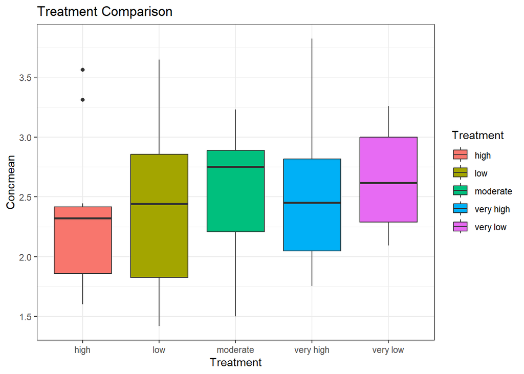

```r
#ix

library(ggplot2)

#A box plot to do treatment comparison
plot_boxplot <- ggplot(func_merged_df, aes(x = Treatment, y = Concmean, fill = Treatment)) +
  geom_boxplot() +
  labs(title = "Treatment Comparison",
       x = "Treatment",
       y = "Concmean") +
  theme_bw()
plot_boxplot
```

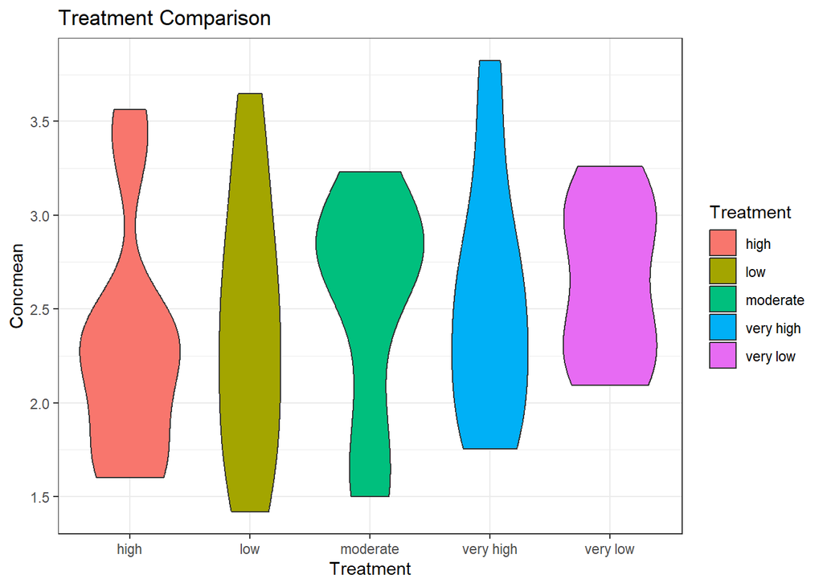

```r
ggsave("boxplot.png", plot_boxplot, width = 8, height = 6, units = "in", dpi = 300)

#A violin plot to do treatment comparison
plot_violin <- ggplot(func_merged_df, aes(x = Treatment, y = Concmean, fill = Treatment)) +
  geom_violin() +
  labs(title = "Treatment Comparison",
       x = "Treatment",
       y = "Concmean") +
  theme_bw()
plot_violin
```

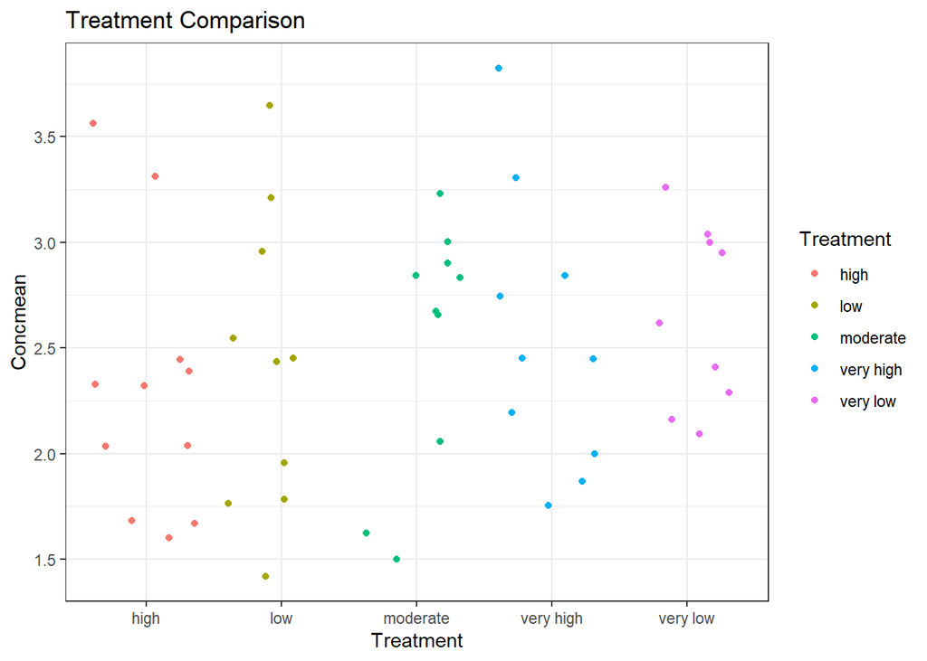

```r
ggsave("violin_plot.png", plot_violin, width = 8, height = 6, units = "in", dpi = 300)

#A scatter plot to do treatment comparison
plot_scatter <- ggplot(func_merged_df, aes(x = Treatment, y = Concmean, color = Treatment)) +
  geom_jitter() +
  labs(title = "Treatment Comparison",
       x = "Treatment",
       y = "Concmean") +
  theme_bw()
plot_scatter
```

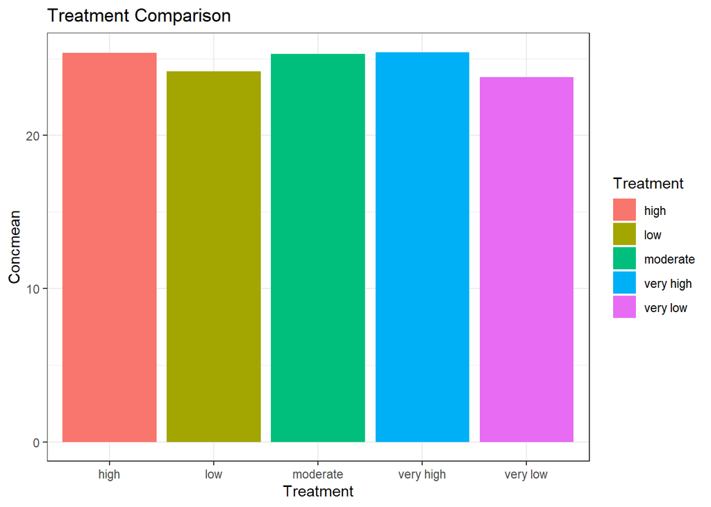

```r
ggsave("scatter_plot.png", plot_scatter, width = 8, height = 6, units = "in", dpi = 300)

#A bar plot to do treatment comparison
plot_bar <- ggplot(func_merged_df, aes(x = Treatment, y = Concmean, fill = Treatment)) +
  geom_bar(stat = "identity") +
  labs(title = "Treatment Comparison",
       x = "Treatment",
       y = "Concmean") +
  theme_bw()
plot_bar
```

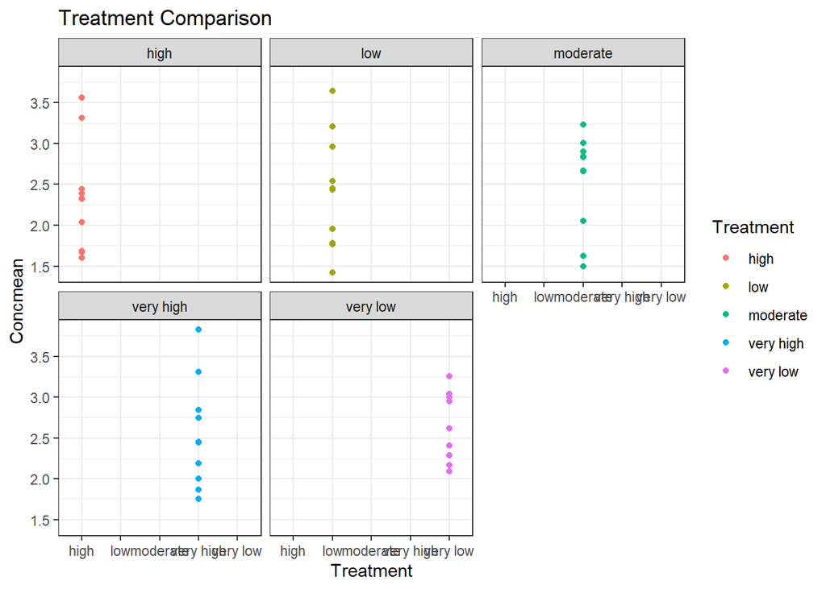

```r
ggsave("bar_plot.png", plot_bar, width = 8, height = 6, units = "in", dpi = 300)

#A faceted plot to do treatment comparison
plot_faceted <- ggplot(func_merged_df, aes(x = Treatment, y = Concmean, color = Treatment)) +
  geom_point() +
  facet_wrap(~Treatment) +
  labs(title = "Treatment Comparison",
       x = "Treatment",
       y = "Concmean") +
  theme_bw()
plot_faceted
```

```r
ggsave("faceted_plot.png", plot_faceted, width = 8, height = 6, units = "in", dpi = 300)
```

#This is the part about classical hypothesis testing

```r
library(knitr)
 stats<- read.csv("statsFile.csv")
kable(stats)
```

| X | BMI | BP | Gender | Status | Location |
| --- | --- | --- | --- | --- | --- |
| P_ 1 | 3.306331 | 1.848332 | Male | 1 | C |
| P_ 2 | 3.144198 | 1.803189 | Female | 0 | C |
| P_ 3 | 3.268586 | 1.837923 | Female | 1 | B |
| P_ 4 | 3.175555 | 1.812009 | Male | 1 | C |
| P_ 5 | 3.084312 | 1.786221 | Female | 1 | A |
| P_ 6 | 3.227014 | 1.826389 | Female | 1 | C |
| P_ 7 | 2.810668 | 1.706505 | Male | 1 | A |
| P_ 8 | 3.080841 | 1.785232 | Male | 1 | B |
| P_ 9 | 3.127907 | 1.798589 | Male | 1 | C |
| P_ 10 | 2.986719 | 1.758213 | Female | 1 | B |
| P_ 11 | 2.877521 | 1.726326 | Female | 0 | B |
| P_ 12 | 3.059652 | 1.779186 | Female | 1 | B |
| P_ 13 | 2.984433 | 1.757551 | Female | 0 | B |
| P_ 14 | 3.425849 | 1.880905 | Male | 1 | B |
| P_ 15 | 3.439004 | 1.884455 | Male | 1 | B |
| P_ 16 | 3.428063 | 1.881503 | Female | 1 | B |
| P_ 17 | 3.122743 | 1.797128 | Female | 0 | B |
| P_ 18 | 2.978352 | 1.755790 | Male | 0 | C |
| P_ 19 | 2.938889 | 1.744319 | Male | 1 | B |
| P_ 20 | 3.179976 | 1.813249 | Male | 0 | C |
| P_ 21 | 3.127935 | 1.798597 | Male | 1 | B |
| P_ 22 | 3.274198 | 1.839474 | Female | 1 | B |
| P_ 23 | 2.963454 | 1.751469 | Male | 0 | A |
| P_ 24 | 3.445759 | 1.886276 | Female | 0 | B |
| P_ 25 | 3.228358 | 1.826763 | Female | 1 | C |
| P_ 26 | 2.840086 | 1.715256 | Female | 0 | C |
| P_ 27 | 3.281707 | 1.841548 | Male | 1 | C |
| P_ 28 | 3.273761 | 1.839354 | Male | 0 | B |
| P_ 29 | 3.279747 | 1.841007 | Male | 0 | B |
| P_ 30 | 3.257726 | 1.834917 | Male | 1 | A |

[output cut: 290 more lines]

```r
# i - A Correlation test to examine how BMI relates to BP

cor(stats$BMI, stats$BP, method = "pearson")
```

```
## [1] 0.9997509
```

```r
cor.test(stats$BMI, stats$BP)
```

```
##
##  Pearson's product-moment correlation
##
## data:  stats$BMI and stats$BP
## t = 798.75, df = 318, p-value < 2.2e-16
## alternative hypothesis: true correlation is not equal to 0
## 95 percent confidence interval:
##  0.9996895 0.9998001
## sample estimates:
##       cor
## 0.9997509
```

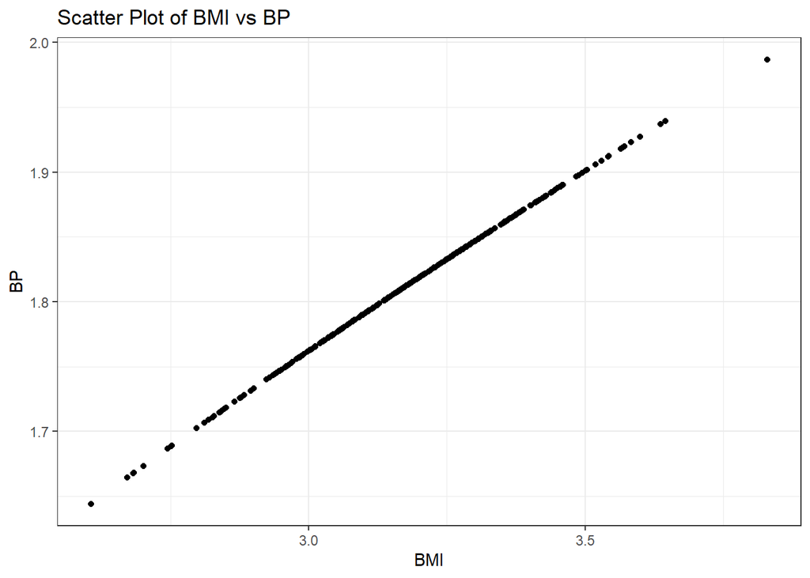

```r
plot <- ggplot(stats, aes(x = BMI, y = BP)) +
  geom_point() +
  labs(title = "Scatter Plot of BMI vs BP",
       x = "BMI",
       y = "BP") +
  theme_bw()

print(plot)
```

Analysis 1: Pearson Correlation Choice of Method/Technique:

Method: Pearson correlation coefficient. Assumptions: Both variables (BMI and BP) are continuous. The relationship between the variables is linear. The data is bivariate normally distributed.

Interpretation: The Pearson correlation coefficient is 0.9997509, indicating an extremely strong positive linear relationship between BMI and BP. The p-value is < 2.2e-16, suggesting that this correlation is statistically significant. The confidence interval (0.9996895, 0.9998001) is very narrow, emphasizing the precision of the estimated correlation.

Analysis 2: Correlation Hypothesis Test

Method: Correlation hypothesis test using cor.test(). The correlation hypothesis test confirms the results obtained from the correlation coefficient calculation. The null hypothesis (true correlation is equal to 0) is rejected, indicating a significant correlation. The t-value is 798.75 with a p-value < 2.2e-16, supporting the rejection of the null hypothesis. The 95% confidence interval (0.9996895, 0.9998001) further strengthens the evidence for a strong positive correlation and since zero doesn’t lie within the range of the confidence interval, we can reject the null hypothesis

In conclusion, both approaches (correlation coefficient and hypothesis test) lead to the same conclusion of a highly significant and strong positive correlation between BMI and BP.

```r
# i - A var.test to examine how BMI relates to BP
stats
```

```
##          X      BMI       BP Gender Status Location
## 1     P_ 1 3.306331 1.848332   Male      1        C
## 2     P_ 2 3.144198 1.803189 Female      0        C
## 3     P_ 3 3.268586 1.837923 Female      1        B
## 4     P_ 4 3.175555 1.812009   Male      1        C
## 5     P_ 5 3.084312 1.786221 Female      1        A
## 6     P_ 6 3.227014 1.826389 Female      1        C
## 7     P_ 7 2.810668 1.706505   Male      1        A
## 8     P_ 8 3.080841 1.785232   Male      1        B
## 9     P_ 9 3.127907 1.798589   Male      1        C
## 10   P_ 10 2.986719 1.758213 Female      1        B
## 11   P_ 11 2.877521 1.726326 Female      0        B
## 12   P_ 12 3.059652 1.779186 Female      1        B
## 13   P_ 13 2.984433 1.757551 Female      0        B
## 14   P_ 14 3.425850 1.880905   Male      1        B
```

[output cut: 306 more lines]

```r
var.test(stats$BMI, stats$BP)#comparing variances, the F test
```

```
##
##  F test to compare two variances
##
## data:  stats$BMI and stats$BP
## F = 12.648, num df = 319, denom df = 319, p-value < 2.2e-16
## alternative hypothesis: true ratio of variances is not equal to 1
## 95 percent confidence interval:
##  10.15190 15.75872
## sample estimates:
## ratio of variances
##           12.64836
```

Analysis: Variance Comparison (F-test)

Method: F-test to compare the variances of BMI and BP.

Assumptions: Both BMI and BP are continuous variables. The populations from which BMI and BP are drawn are normally distributed. The samples are independent

Interpretation: The F-test results in an F-statistic of 12.648 with a p-value < 2.2e-16. The null hypothesis (true ratio of variances is equal to 1) is rejected, suggesting that the variances of BMI and BP are significantly different. The 95% confidence interval for the ratio of variances is (10.15190, 15.75872). The sample estimate for the ratio of variances is 12.64836.

In conclusion, the extremely low p-value suggests a significant difference in variances between BMI and BP.

```r
# i (A to.test to examine how BMI relates to BP)
t.test(stats$BMI, stats$BP)#comparing means
```

```
##
##  Welch Two Sample t-test
##
## data:  stats$BMI and stats$BP
## t = 121.36, df = 369.13, p-value < 2.2e-16
## alternative hypothesis: true difference in means is not equal to 0
## 95 percent confidence interval:
##  1.349605 1.394060
## sample estimates:
## mean of x mean of y
##  3.185907  1.814074
```

Analysis: Welch’s Two-Sample t-test for Comparing Means

Method: Welch’s Two-Sample t-test for comparing the means of BMI and BP.

Assumptions: Both BMI and BP are continuous variables. The populations from which BMI and BP are drawn are approximately normally distributed. The samples are independent.

Welch’s t-test results in a t-statistic of 121.36 with a p-value < 2.2e-16. The null hypothesis (true difference in means is equal to 0) is strongly rejected. The 95% confidence interval for the difference in means is (1.349605, 1.394060) and zero doesn’t lie there. The sample estimates for the mean of BMI and BP are 3.185907 and 1.814074, respectively.

In conclusion,Welch’s t-test as we assume unequal variances. The extremely low p-value suggests a significant difference in means between BMI and BP. The confidence interval for the difference in means gives a range of plausible values for the true difference.

```r
# ii (A chi square test to examine how disease status is related to gender)
chisq_result <- chisq.test(table(stats$Status, stats$Gender))
print(chisq_result)
```

```
##
##  Pearson's Chi-squared test with Yates' continuity correction
##
## data:  table(stats$Status, stats$Gender)
## X-squared = 0.86632, df = 1, p-value = 0.352
```

Analysis: Chi-squared Test for Independence

Method: Pearson’s Chi-squared test with Yates’ continuity correction.

Assumptions: Categorical variables: Disease Status (stats$Status) and Gender (stats$Gender). Expected frequencies are greater than 5 for each group.

Interpretation:

The chi-squared test results in a chi-squared statistic of 0.86632 with 1 degree of freedom and a p-value of 0.352. At a significance level of 0.05, the p-value indicates that there is insufficient evidence to reject the null hypothesis( There is no association between disease status and gender.), suggesting no statistically significant association between disease status and gender in the given sample. Therefore disease status and gender are not significantly linked.

In conclusion,the chi-squared test for independence was suitable to test whether there was a significant association between the two categorical variables. It was chosen because we had two qualitative independent variables with expected frequency greater than five

```r
# iii (A model to show the relationship between BMI and BP)
model <- lm(BP ~ BMI, data = stats)

summary(model)
```

```
##
## Call:
## lm(formula = BP ~ BMI, data = stats)
##
## Residuals:
##        Min         1Q     Median         3Q        Max
## -0.0080845 -0.0001705  0.0004430  0.0007507  0.0008477
##
## Coefficients:
##              Estimate Std. Error t value Pr(>|t|)
## (Intercept) 0.9184871  0.0011233   817.6   <2e-16 ***
## BMI         0.2811090  0.0003519   798.7   <2e-16 ***
## ---
## Signif. codes:  0 '***' 0.001 '**' 0.01 '*' 0.05 '.' 0.1 ' ' 1
##
## Residual standard error: 0.001224 on 318 degrees of freedom
## Multiple R-squared:  0.9995, Adjusted R-squared:  0.9995
## F-statistic: 6.38e+05 on 1 and 318 DF,  p-value: < 2.2e-16
```

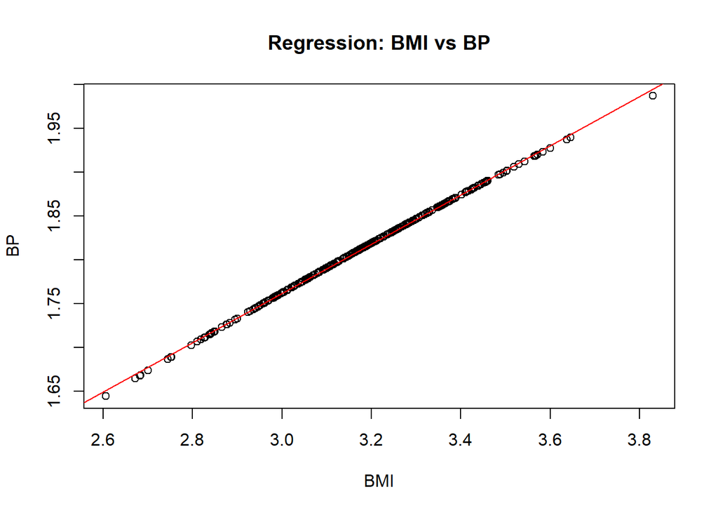

```r
plot(stats$BMI, stats$BP, main = "Regression: BMI vs BP", xlab = "BMI", ylab = "BP")
abline(model, col = "red")
```

Analysis: Simple Linear Regression

Method: Simple linear regression with Blood Pressure (BP) as the response variable and Body Mass Index (BMI) as the predictor variable. Simple linear regression is suitable for testing the linear relationship between two continuous variables as it is in thus case.

Assumptions: Linear relationship between BMI and BP. Residuals are normally distributed. Homoscedasticity (constant variance of residuals). Independence of residuals.

Interpretation:

The regression model is given by BP=0.9184871+0.2811090×BMI. The coefficient for BMI is statistically significant (p-value < 2.2e-16), indicating a significant linear relationship. The intercept (0.9184871) represents the estimated BP when BMI is 0 The R squared value is 0.9995, indicating that 99.95% of the variability in BP can be explained by the linear relationship with BMI. The p-value for the F-statistic is < 2.2e-16, suggesting that the model as a whole is statistically significant

In conclusion, the extremely low p-values for both the intercept and the slope suggest a highly significant relationship between BMI and BP.

```r
library(ggplot2)
#iv (Testing how BMI compares in the different sampling locations)
stats%>%group_by(Location)%>%summarize(mean=mean(BMI), median=median(BMI))
```

```
## # A tibble: 3 × 3
##   Location  mean median
##   <chr>    <dbl>  <dbl>
## 1 A         3.18   3.21
## 2 B         3.21   3.19
## 3 C         3.17   3.17
```

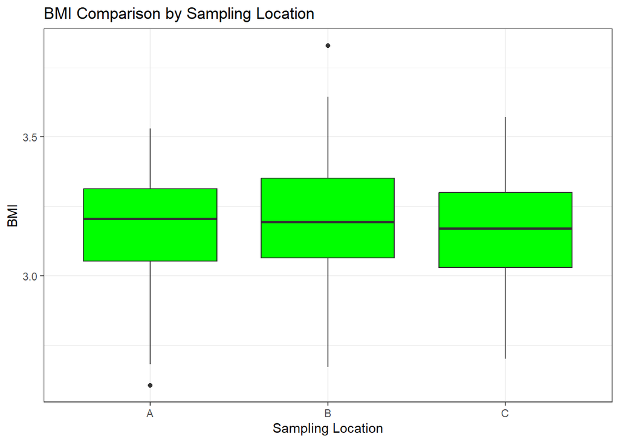

```r
# Box plot
ggplot(stats, aes(x = Location, y = BMI)) +
  geom_boxplot(fill = "green") +
  labs(title = "BMI Comparison by Sampling Location", x = "Sampling Location", y = "BMI")+
  theme_bw()
```

```r
# Testing the variance
stats%>%group_by(Location)%>%summarize(variance_BMI = var(BMI))
```

```
## # A tibble: 3 × 2
##   Location variance_BMI
##   <chr>           <dbl>
## 1 A              0.0369
## 2 B              0.0395
## 3 C              0.0367
```

```r
#anova test
location_count <- table(stats$Location)
anova_result <- aov(BMI ~ Location, data = stats)
summary(anova_result)
```

```
##              Df Sum Sq Mean Sq F value Pr(>F)
## Location      2  0.097 0.04834   1.278   0.28
## Residuals   317 11.991 0.03782
```

Method: Analysis of Variance (ANOVA) to compare means of BMI across different sampling locations. The ANOVA test was chosen because it is appropriate when comparing means across three or more groups.

Assumptions: Independence of observations. Normally distributed residuals. Homogeneity of variances.

Interpretation: The ANOVA results indicate that there is no significant difference in mean BMI across the different sampling locations.The main effect of location is not statistically significant and very small The p-value for the F-statistic is 0.28, which is greater than the significance level of 0.05. The null hypothesis (no difference in means) is not rejected at the 5% significance level.

```r
#v  (A model showing how disease status depends on both BMI and BP)
model2 <- glm(Status ~ BMI + BP, data = stats, family = "binomial")
summary(model2)
```

```
##
## Call:
## glm(formula = Status ~ BMI + BP, family = "binomial", data = stats)
##
## Coefficients:
##             Estimate Std. Error z value Pr(>|z|)
## (Intercept)   -11.64      84.53  -0.138    0.890
## BMI            -4.15      25.88  -0.160    0.873
## BP             13.67      92.02   0.149    0.882
##
## (Dispersion parameter for binomial family taken to be 1)
##
##     Null deviance: 443.30  on 319  degrees of freedom
## Residual deviance: 442.99  on 317  degrees of freedom
## AIC: 448.99
##
## Number of Fisher Scoring iterations: 3
```

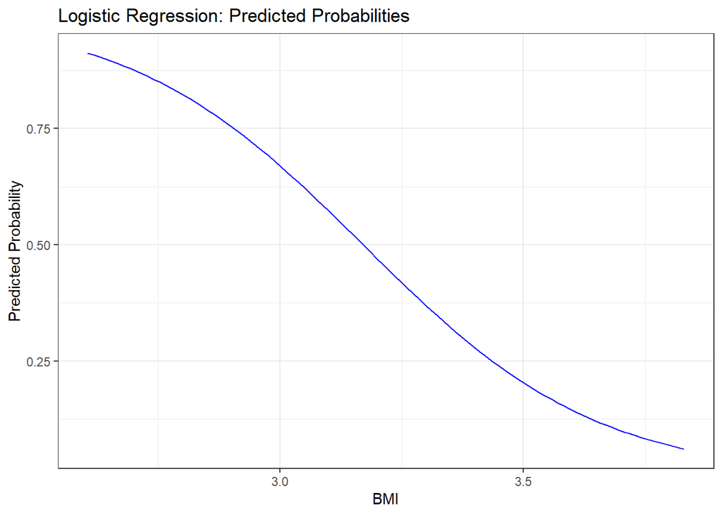

```r
bmi_values <- seq(min(stats$BMI), max(stats$BMI), length.out = 100)# Creating a sequence of BMI values

plot_data <- data.frame(BMI = bmi_values, BP = mean(stats$BP))# Creating a data frame with constant BP values and varying BMI values

plot_data$Predicted_Prob <- predict(model2, newdata = plot_data, type = "response")# Predicting probabilities using the logistic regression model

# Plotting the predicted probabilities
library(ggplot2)

ggplot(plot_data, aes(x = BMI, y = Predicted_Prob)) +
  geom_line(color = "blue") +
  labs(title = "Logistic Regression: Predicted Probabilities",
       x = "BMI",
       y = "Predicted Probability") +
  theme_bw()
```

Analysis: Logistic Regression Model

Method: Logistic Regression with Disease Status (Status) as the binary response variable and predictors as Body Mass Index (BMI) and Blood Pressure (BP).

Assumptions: The relationship between the log odds of the outcome and predictors is linear. Independence of observations. Absence of multicollinearity. Adequate sample size for reliable estimates.

Interpretation: The logistic regression model is given by log(P/(1-P)= −11.64 − 4.15 × BMI + 13.67 × BP where p is the probability of having the disease (Status).

Coefficients: Intercept: -11.64 BMI: -4.15 BP: 13.67

Significance of Coefficients: The p-values for all coefficients are greater than 0.05, suggesting that none of the predictors are statistically significant in predicting the disease status.

Model Fit:

The null deviance is 443.30, and the residual deviance is 442.99. The difference between these deviances (Chi-squared statistic) is not significant, indicating that the model does not significantly improve the fit compared to a model with no predictors.